# Spatial Smooths for Joint Model Output

# Purpose

The purpose of this script is to take the output of the QM/qPCR joint model and apply simple spatial models to it to make smoothed output maps.

```r
library(tidyverse)
library(sf)
library(sdmTMB)
library(viridis)
library(cowplot)
library(here)
library(marmap)
library(visreg)
options(dplyr.summarise.inform=FALSE)
knitr::opts_chunk$set(warning=FALSE,message=FALSE,echo = F,error=F)
```

# Load Data

Load data from the joint model output. These data have estimates of copy numbers for species in the metabarcoding data. The data also include spatial information on where each sample was collected (lat,lon,depth).

```
Rows: 2,046
Columns: 25
$ variable          <chr> "log_D[1,1]", "log_D[1,2]", "log_D[1,3]", "log_D[1,4…
$ mean              <dbl> 2.9649118, 5.0855464, 4.4484285, -6.2896547, -6.6501…
$ se_mean           <dbl> 0.007717553, 0.006573863, 0.007050941, 0.134780573, …
$ sd                <dbl> 0.1250507, 0.1149754, 0.1176431, 2.6501115, 2.608466…
$ `2.5%`            <dbl> 2.7262886, 4.8633785, 4.2292117, -12.6960169, -12.56…
$ `25%`             <dbl> 2.8800496, 5.0160361, 4.3662987, -7.7370993, -7.9107…
$ `50%`             <dbl> 2.9635638, 5.0876639, 4.4457414, -5.7713375, -6.1642…
$ `75%`             <dbl> 3.0469772, 5.1603812, 4.5220846, -4.3383036, -4.8029…
$ `97.5%`           <dbl> 3.1923226, 5.3169677, 4.6841176, -2.5022807, -2.9318…
$ n_eff             <dbl> 262.55065, 305.89217, 278.38031, 386.61053, 180.4494…
$ Rhat              <dbl> 1.0094285, 1.0181211, 1.0196721, 1.0009346, 1.018442…
$ taxa              <int> 1, 2, 3, 4, 5, 6, 1, 2, 3, 4, 5, 6, 1, 2, 3, 4, 5, 6…
$ species           <chr> "Clupea pallasii", "Merluccius productus", "Sardinop…
$ tubeID            <chr> "460", "460", "460", "460", "460", "460", "488", "48…
$ tube_idx          <int> 17, 17, 17, 17, 17, 17, 18, 18, 18, 18, 18, 18, 28, …
$ station_depth_idx <int> 200, 200, 200, 200, 200, 200, 210, 210, 210, 210, 21…
$ station_idx       <int> 46, 46, 46, 46, 46, 46, 49, 49, 49, 49, 49, 49, 99, …
$ raw_reads         <int> 443, 5226, 2126, 0, 0, 0, 0, 1570, 0, 0, 501, 0, 0, …
$ station           <chr> "39-1", "39-1", "39-1", "39-1", "39-1", "39-1", "39-…
$ lat               <dbl> 40.72985, 40.72985, 40.72985, 40.72985, 40.72985, 40…
$ lon               <dbl> -124.3735, -124.3735, -124.3735, -124.3735, -124.373…
$ depth             <dbl> 0, 0, 0, 0, 0, 0, 0, 0, 0, 0, 0, 0, 50, 50, 50, 50, …
$ depth_cat         <dbl> 0, 0, 0, 0, 0, 0, 0, 0, 0, 0, 0, 0, 50, 50, 50, 50, …
$ wash_idx          <dbl> 0, 0, 0, 0, 0, 0, 0, 0, 0, 0, 0, 0, 0, 0, 0, 0, 0, 0…
$ sampleidx         <int> 368, 368, 368, 368, 368, 368, 373, 373, 373, 373, 37…
```

# Spatial Domain

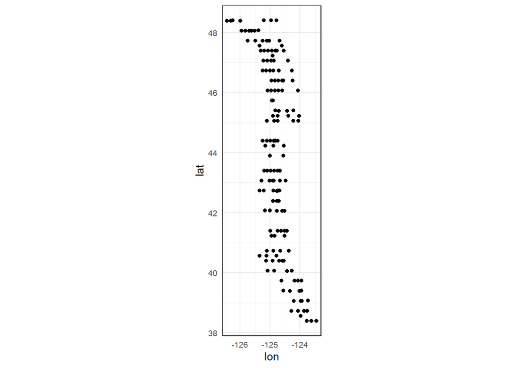

Set up the appropriate spatial domain for the spatial smooths, and make a prediction grid for projecting the outputs

## Plot Raw Data

We can plot the raw reads from metabarcoding, the fitted concentrations from the joint model, and their relative difference

### Raw Reads

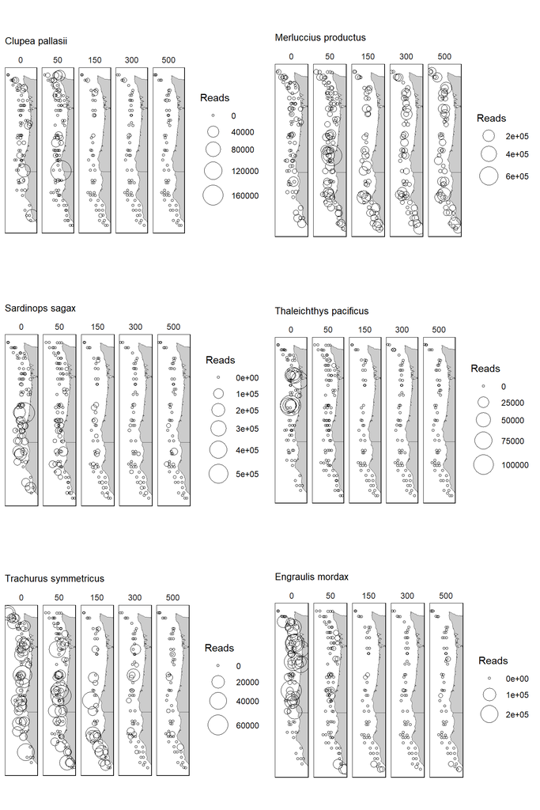

### Concentration

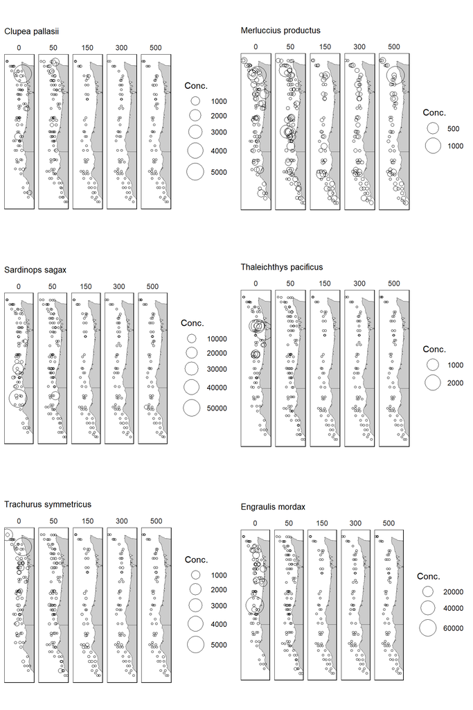

### Relative Difference

One way we can plot the relative difference maps is to put reads and copies on a 0-1 scale and then difference them. For now we just divide by the maximum value (instead of, e.g., z-scoring).

In these maps, blue circles show samples where the raw reads are higher on the relative scale than the model-corrected eDNA concentrations, while the yellow triangles show samples where the model-corrected eDNA concentrations are larger than the raw reads. This figure gives a sense, for each species, how the spatial pattern changes when moving from uncorrected reads into true concentration space.

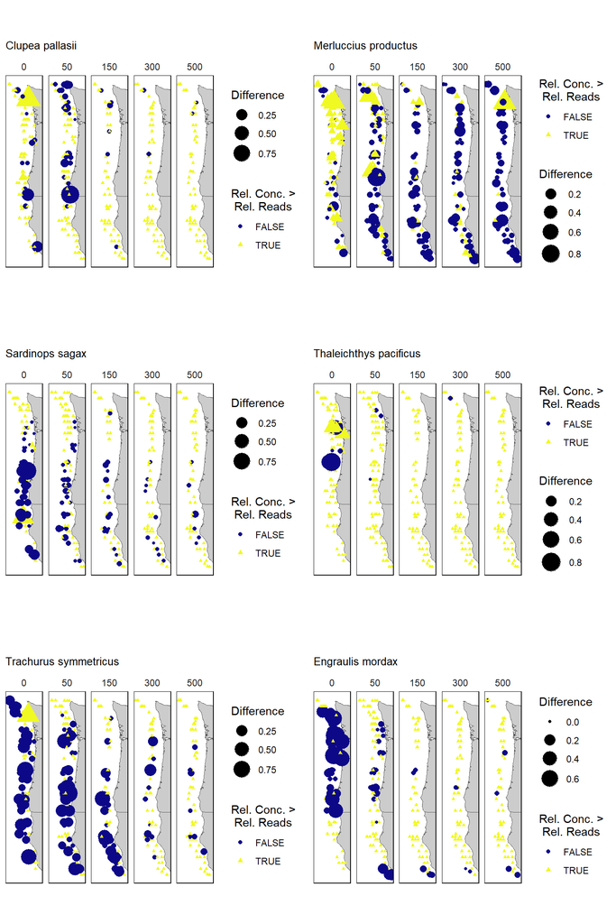

### Non-spatial Depth Pattern

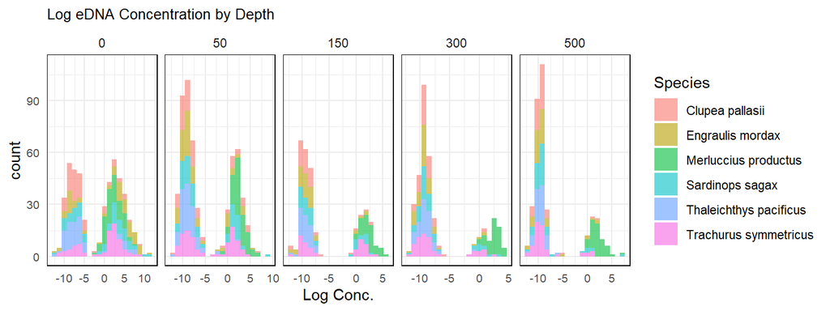

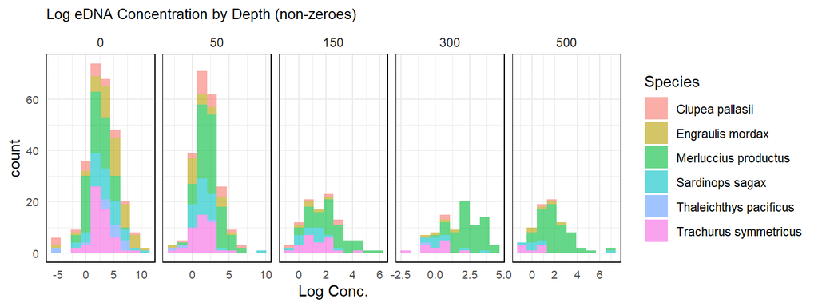

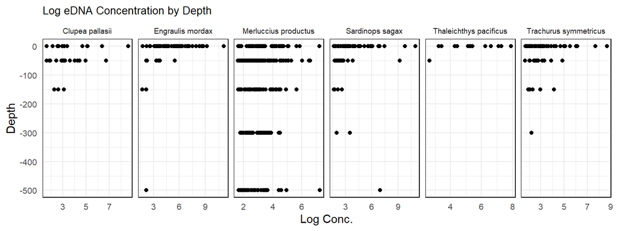

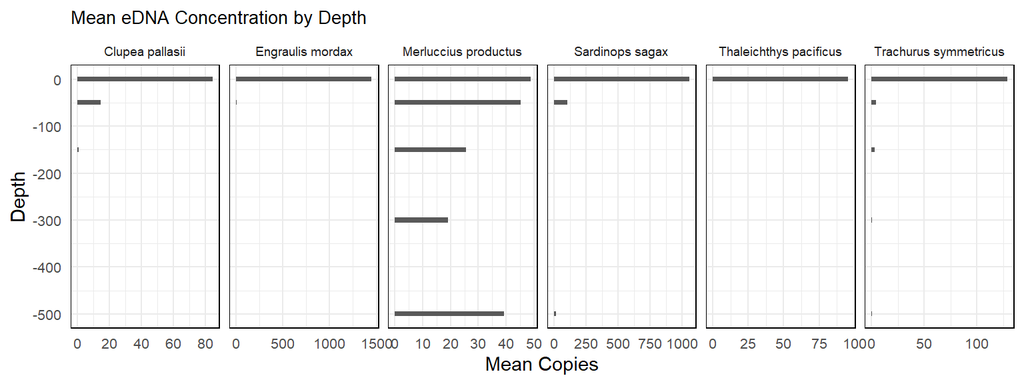

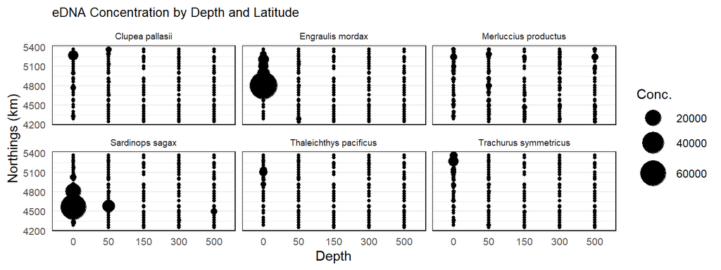

## Projection Grid

Based on the bounding box of the data, make a grid for model projection.

Another option using the convex/concave hull

## Bathymetry

Here’s a covariate for water depth (bathymetry)

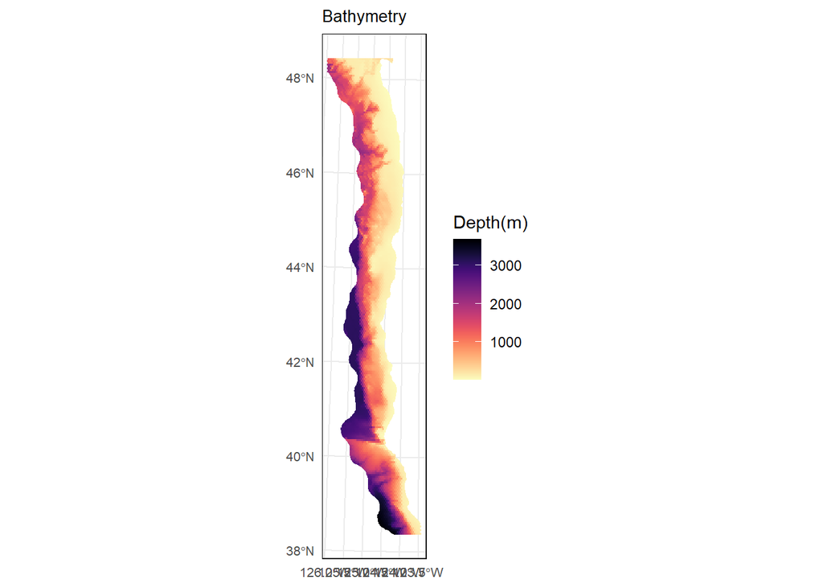

## Distance from Shore

Derive a predictor that measures straight-line distance to the coast.

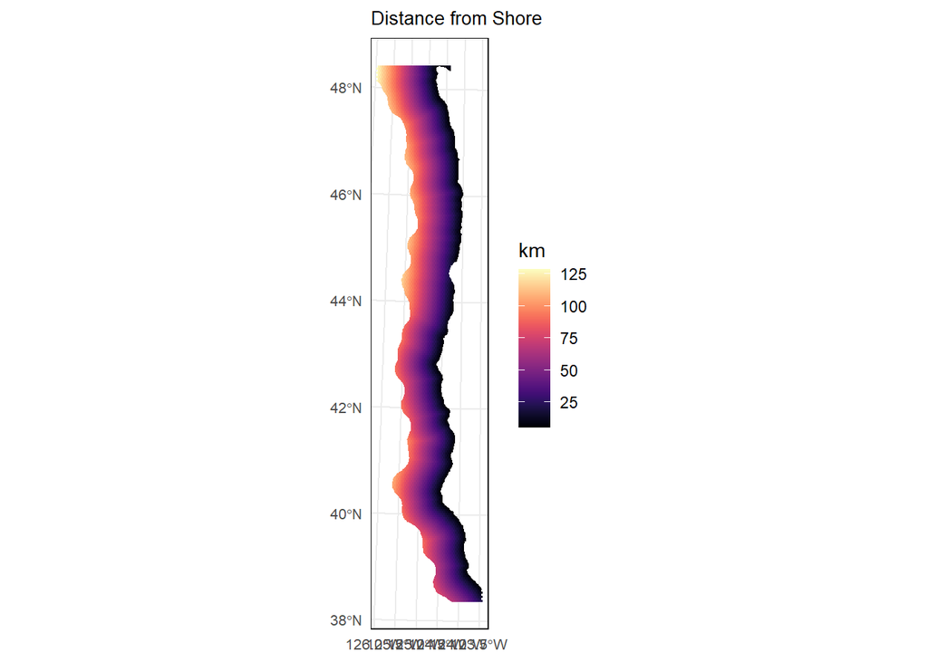

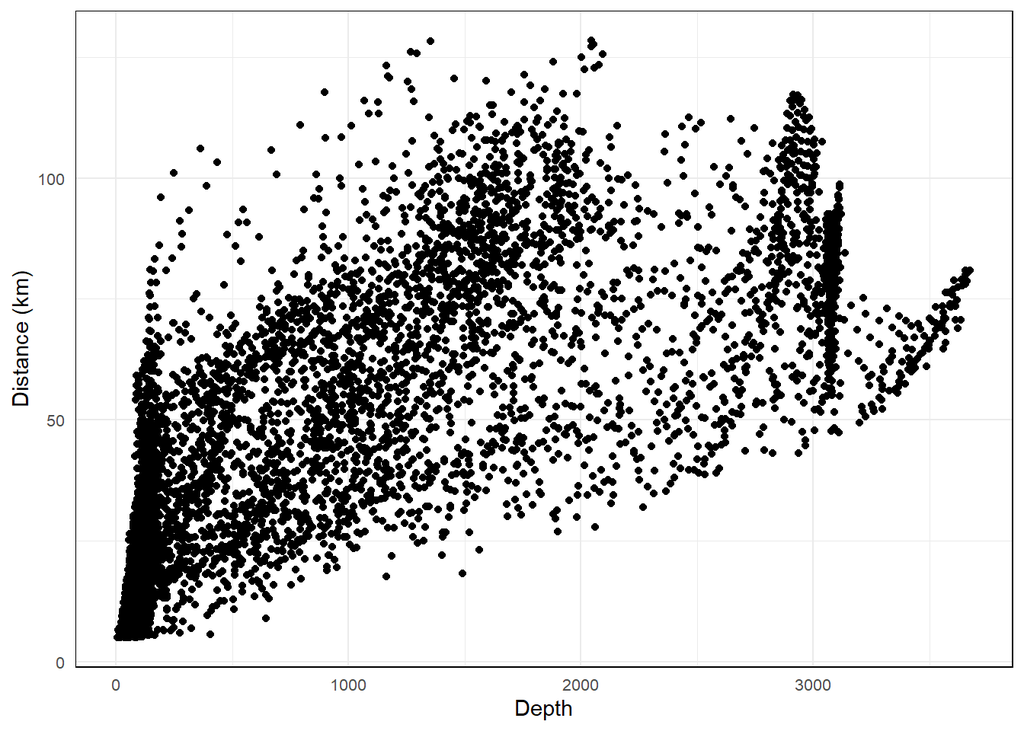

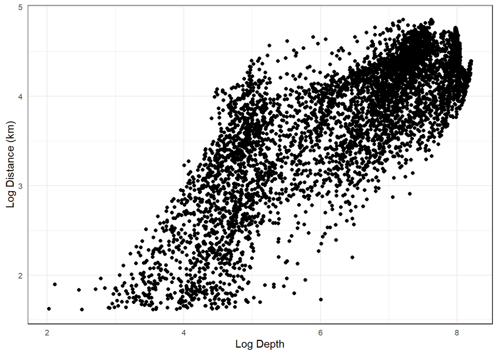

## Distance from Shelf Break (200m isobath)

We can also use a similar approach to derive a predictor that measures straight-line distance to the 200m shelf break

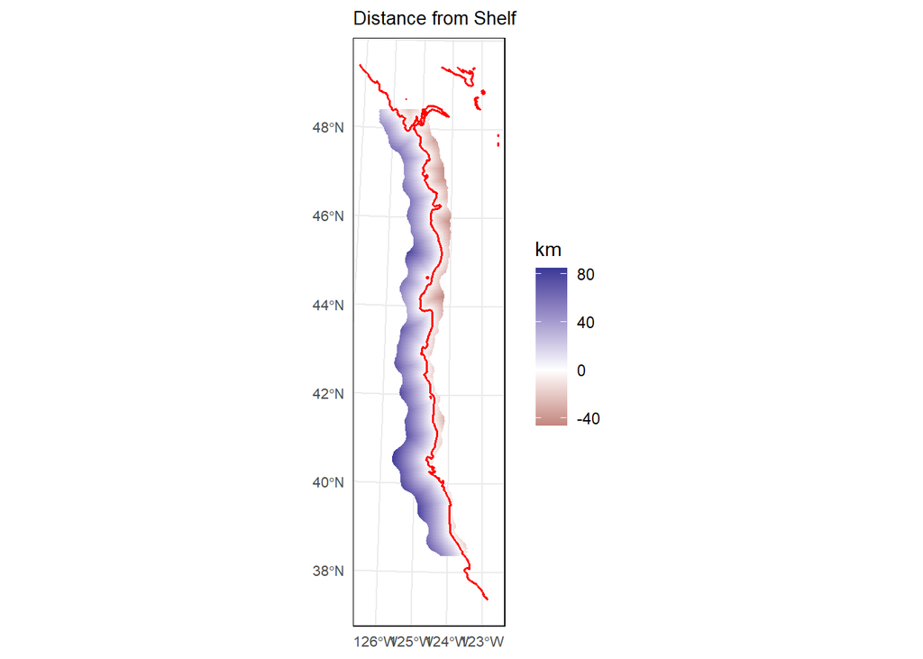

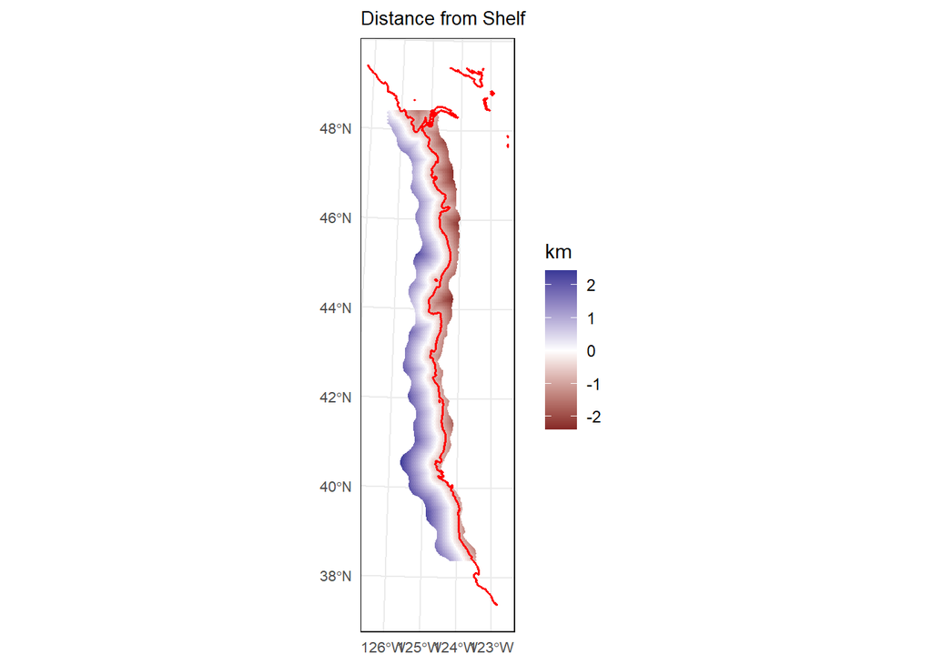

## Depth-expanded Projection

## Depth Integrated

Make a version of the data that is depth-integrated

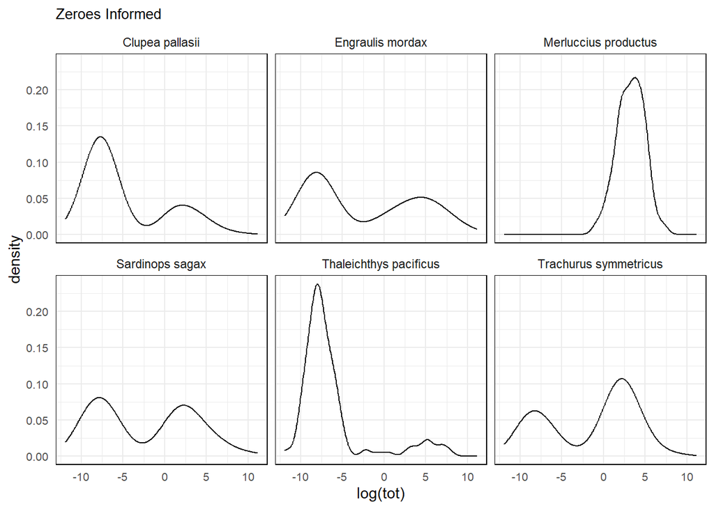

## Zero-informed

In the distributions above, there is a clear delineation for all species except hake at ~ -2 log copies = ~0.14 copies, which is certainly below our detection limit. Let’s make a version of the data where we impose absence as <-2 estimated log copies

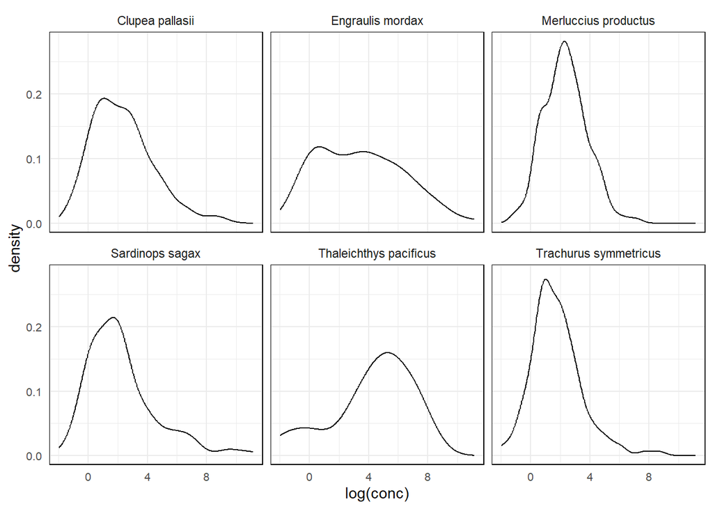

## Model Mesh

Create candidate INLA meshes for the sdmTMB models.

# Run Models

Testing ground

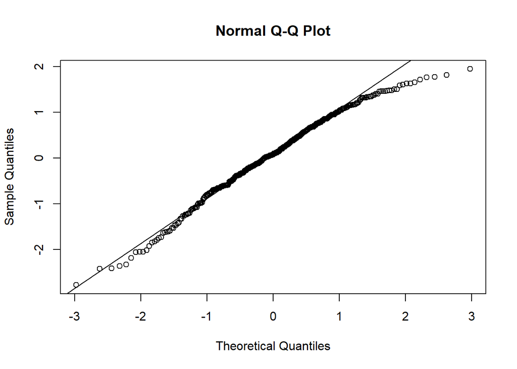

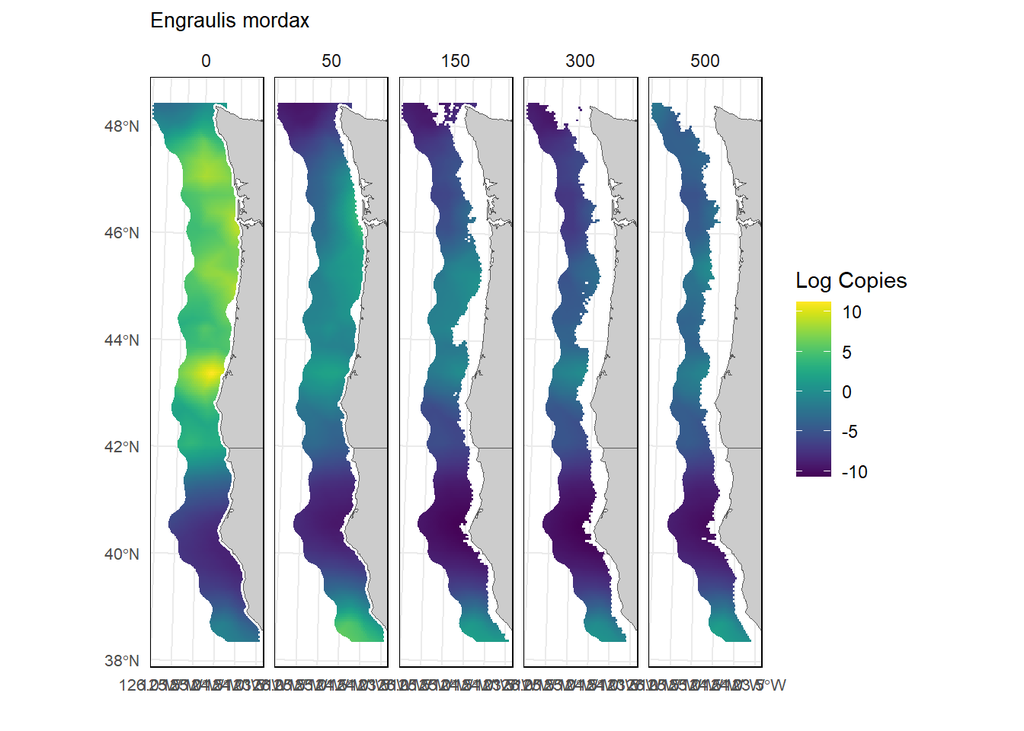

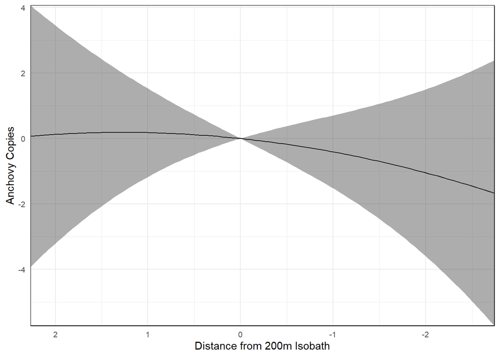

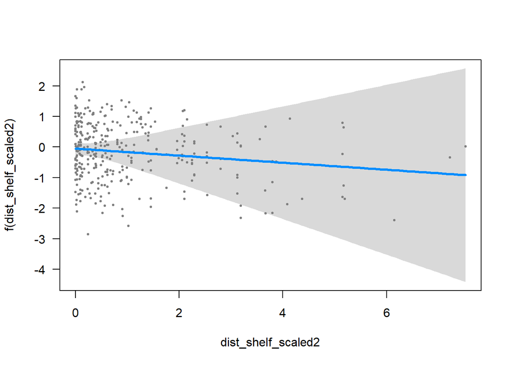

Now, write a function to do this for any species. We’ll stick with the smaller projection domain for now, and will adopt a consistent model equation form

## Mesh Complexity Test

For each species, we find the mesh (out of a starter set varying in complexity) that leads to the highest likelihood of the SDM.

### Anchovy

```
Error in stats::nlminb(start = tmb_obj$par, objective = tmb_obj$fn, gradient = tmb_obj$gr,  :
  NA/NaN gradient evaluation
[1] "Error."
```

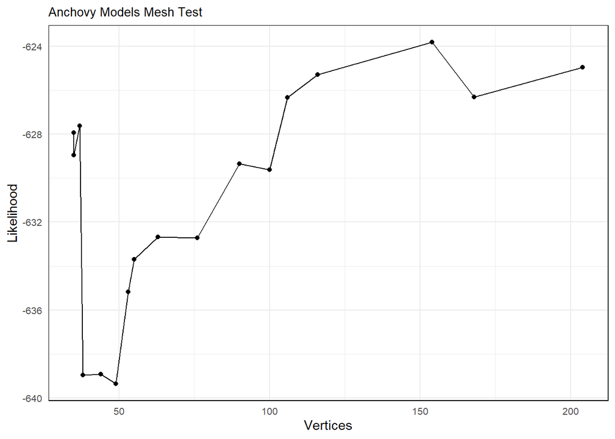

Looks like Mesh 3 is the best for anchovy, with 154 vertices.

### Mackerel

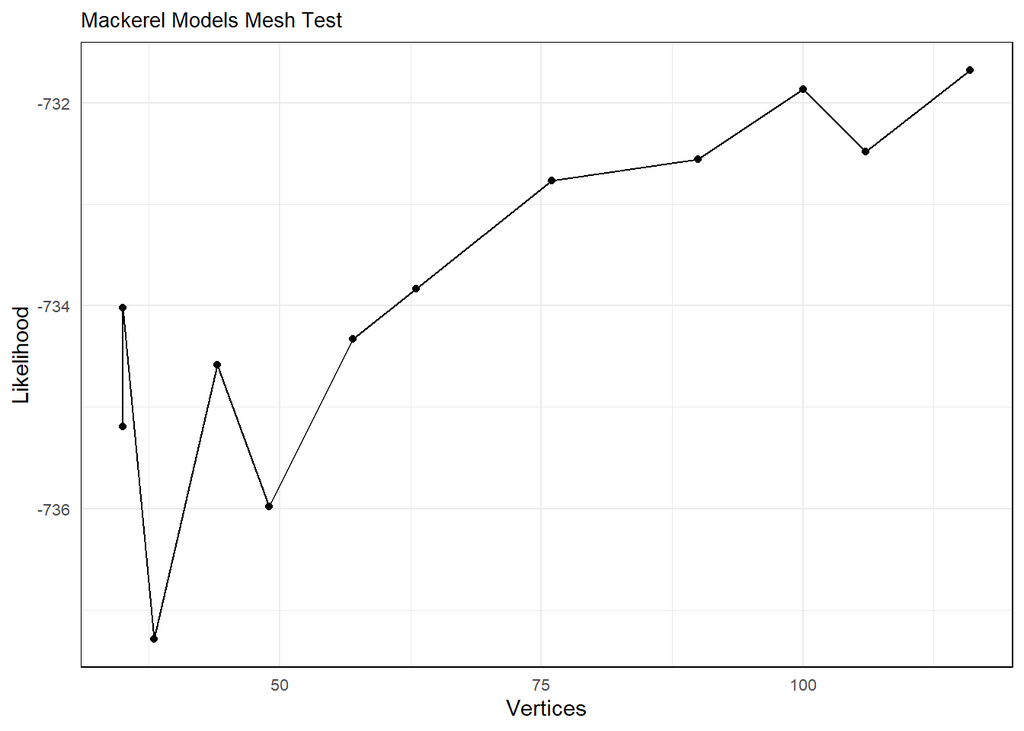

Looks like Mesh 4 is the best for mackerel, with 116 vertices.

### Sardine

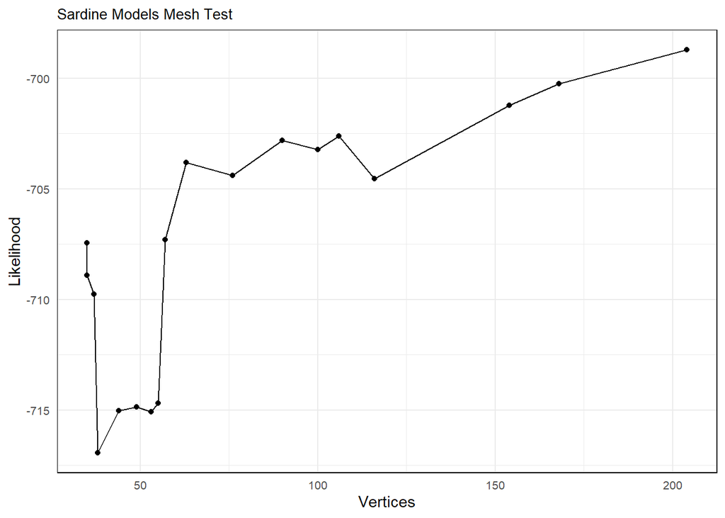

Looks like Mesh 1 is the best for sardine, with 204 vertices.

### Eulachon

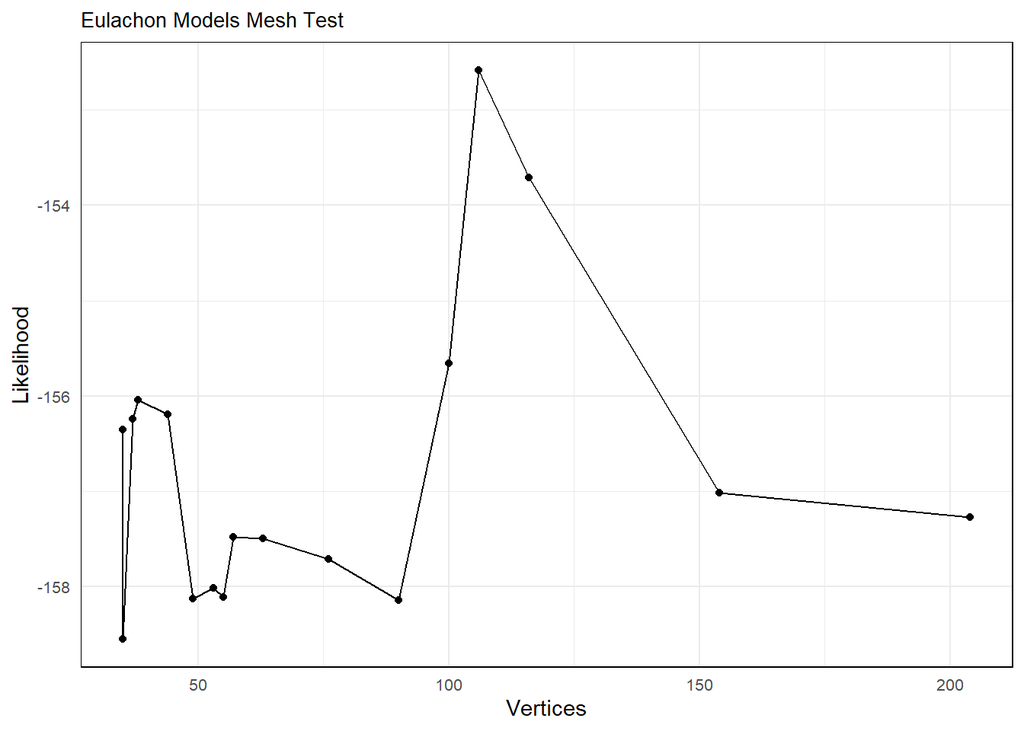

For eulachon, Mesh 5 is the best, with 106 vertices.

### Herring

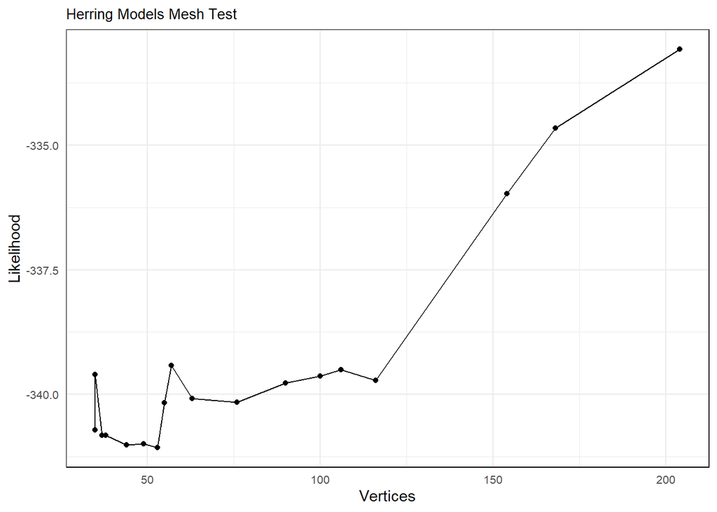

Looks like Mesh 1 is the best for herring, with 204 vertices.

### Hake

Hake is unique because it has no zeroes. We use a lognormal instead of a Tweedie

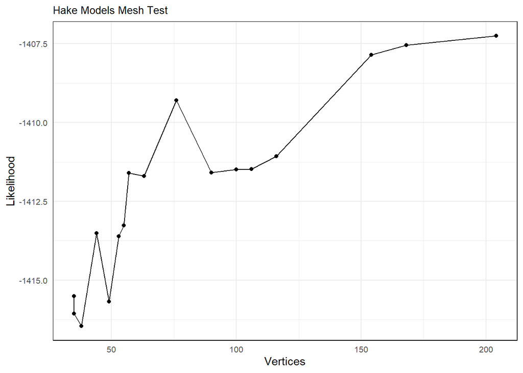

Looks like Mesh 1 is the best for hake, with 204 vertices.

## All Species

Using the chosen mesh and formula from the examples above, try for all species

# Query Outputs

## Inshore/Offshore

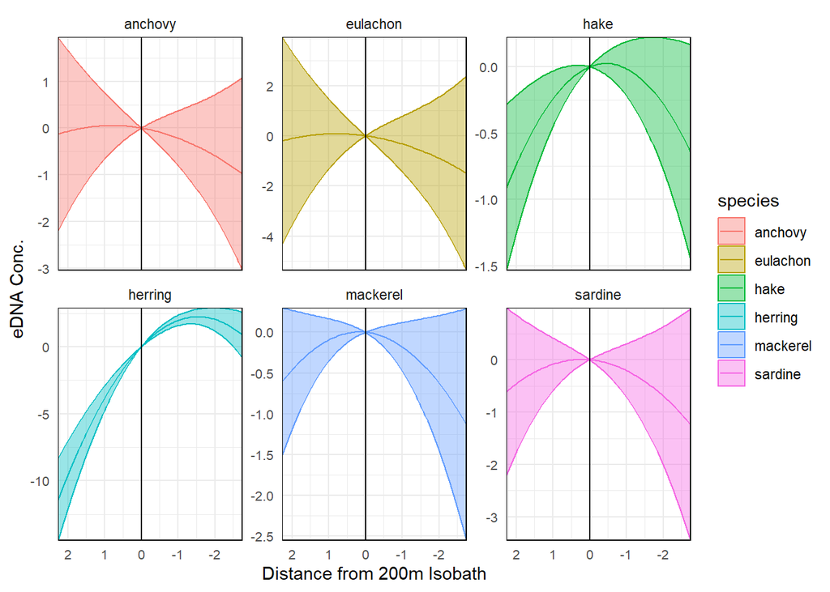

## Species Stacking

We can stack models and look at overlap

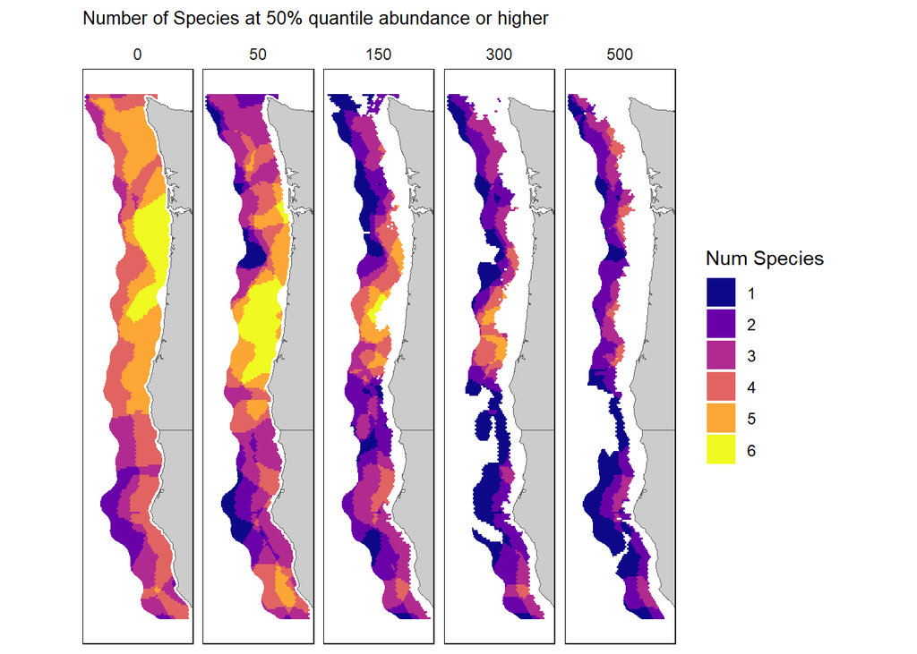

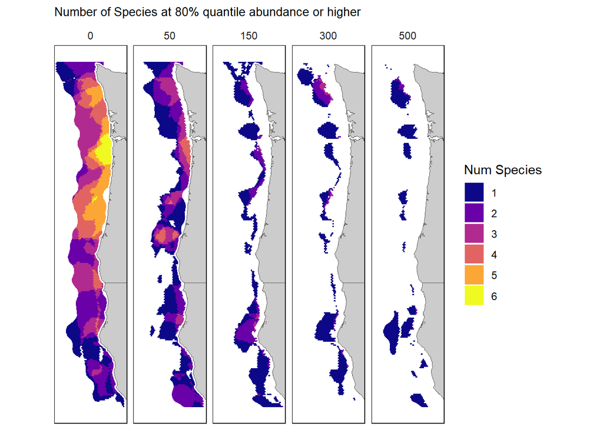